# Social Media

Shubham Bhargava 2024-03-25

```r
library(readxl)
library(dplyr)
library(FactoMineR)
library(factoextra)
social_media <- read_excel("social_media_cleaned.xlsx")


#### Multiple Regression Analysis
```

```r
library(dplyr)
library(readxl)
library(car)
```

```r
library(ggplot2)
library(GGally)
social_media <- read_excel("social_media_cleaned.xlsx")
social_media_numeric <- select_if(social_media, is.numeric)
```

#### Model Development

```r
model <- lm(social_media_numeric$Trouble_falling_asleep  ~ social_media_numeric$Instagram + social_media_numeric$LinkedIn + social_media_numeric$SnapChat + social_media_numeric$Twitter + social_media_numeric$`Whatsapp/Wechat` + social_media_numeric$youtube + social_media_numeric$OTT + social_media_numeric$Reddit,
            data = social_media_numeric
)
summary(model)
```

```
##
## Call:
## lm(formula = social_media_numeric$Trouble_falling_asleep ~ social_media_numeric$Instagram +
##     social_media_numeric$LinkedIn + social_media_numeric$SnapChat +
##     social_media_numeric$Twitter + social_media_numeric$`Whatsapp/Wechat` +
##     social_media_numeric$youtube + social_media_numeric$OTT +
##     social_media_numeric$Reddit, data = social_media_numeric)
##
## Residuals:
##      Min       1Q   Median       3Q      Max
## -0.47240 -0.26171 -0.04857  0.14431  0.71319
##
## Coefficients:
##                                        Estimate Std. Error t value Pr(>|t|)
## (Intercept)                             0.02935    0.36730   0.080    0.938
## social_media_numeric$Instagram          0.07008    0.03479   2.014    0.067 .
## social_media_numeric$LinkedIn          -0.02846    0.04682  -0.608    0.555
## social_media_numeric$SnapChat           0.05725    0.03387   1.690    0.117
## social_media_numeric$Twitter            0.03816    0.14738   0.259    0.800
## social_media_numeric$`Whatsapp/Wechat` -0.02922    0.03663  -0.798    0.441
## social_media_numeric$youtube            0.04025    0.07350   0.548    0.594
## social_media_numeric$OTT               -0.02642    0.05020  -0.526    0.608
## social_media_numeric$Reddit            -0.02379    0.06667  -0.357    0.727
## ---
## Signif. codes:  0 '***' 0.001 '**' 0.01 '*' 0.05 '.' 0.1 ' ' 1
##
## Residual standard error: 0.4432 on 12 degrees of freedom
## Multiple R-squared:  0.495,  Adjusted R-squared:  0.1583
## F-statistic:  1.47 on 8 and 12 DF,  p-value: 0.2639
```

We examine the relevant t- and p-values for each coefficient to determine its statistical significance. A predictor variable may be statistically important in explaining the variability in sleep problems if it has a low p-value, which is often less than 0.05. Put more simply, it indicates that there is a good chance that the variable actually affects sleep problems.

#### Model Acceptance

```r
coefficients(model)
```

```
##                            (Intercept)         social_media_numeric$Instagram
##                             0.02935003                             0.07007642
##          social_media_numeric$LinkedIn          social_media_numeric$SnapChat
##                            -0.02846038                             0.05724962
##           social_media_numeric$Twitter social_media_numeric$`Whatsapp/Wechat`
##                             0.03816260                            -0.02922242
##           social_media_numeric$youtube               social_media_numeric$OTT
##                             0.04025224                            -0.02641988
##            social_media_numeric$Reddit
##                            -0.02379311
```

```r
confint(model,level=0.95)
```

```
##                                               2.5 %     97.5 %
## (Intercept)                            -0.770927154 0.82962722
## social_media_numeric$Instagram         -0.005728035 0.14588087
## social_media_numeric$LinkedIn          -0.130465001 0.07354424
## social_media_numeric$SnapChat          -0.016539324 0.13103857
## social_media_numeric$Twitter           -0.282947122 0.35927233
## social_media_numeric$`Whatsapp/Wechat` -0.109032432 0.05058759
## social_media_numeric$youtube           -0.119892516 0.20039700
## social_media_numeric$OTT               -0.135799283 0.08295953
## social_media_numeric$Reddit            -0.169058947 0.12147272
```

```r
fitted(model)
```

```
##           1           2           3           4           5           6
##  0.03767577  0.68297470 -0.14111191  0.20249080  0.85568960 -0.12780750
##           7           8           9          10          11          12
##  0.23700749  0.28681294  0.47239558  0.13256374  0.41692826  0.27284963
##          13          14          15          16          17          18
##  1.09915634  0.43420708  0.04857065  0.41826973  0.41113911  0.32212351
##          19          20          21
##  0.26171236  0.88332910 -0.20697699
```

#### Residual Analysis

```r
library(car)
residuals(model)
```

```
##           1           2           3           4           5           6
## -0.03767577  0.31702530  0.14111191 -0.20249080  0.14431040  0.12780750
##           7           8           9          10          11          12
## -0.23700749  0.71318706 -0.47239558 -0.13256374  0.58307174 -0.27284963
##          13          14          15          16          17          18
## -0.09915634 -0.43420708 -0.04857065  0.58173027 -0.41113911 -0.32212351
##          19          20          21
## -0.26171236  0.11667090  0.20697699
```

```r
anova(model)
```

```
## Analysis of Variance Table
##
## Response: social_media_numeric$Trouble_falling_asleep
##                                        Df  Sum Sq Mean Sq F value  Pr(>F)
## social_media_numeric$Instagram          1 1.19181 1.19181  6.0682 0.02985 *
## social_media_numeric$LinkedIn           1 0.14215 0.14215  0.7238 0.41156
## social_media_numeric$SnapChat           1 0.54677 0.54677  2.7839 0.12108
## social_media_numeric$Twitter            1 0.00972 0.00972  0.0495 0.82772
## social_media_numeric$`Whatsapp/Wechat`  1 0.26490 0.26490  1.3488 0.26808
## social_media_numeric$youtube            1 0.04226 0.04226  0.2152 0.65103
## social_media_numeric$OTT                1 0.08720 0.08720  0.4440 0.51780
## social_media_numeric$Reddit             1 0.02501 0.02501  0.1274 0.72739
## Residuals                              12 2.35684 0.19640
## ---
## Signif. codes:  0 '***' 0.001 '**' 0.01 '*' 0.05 '.' 0.1 ' ' 1
```

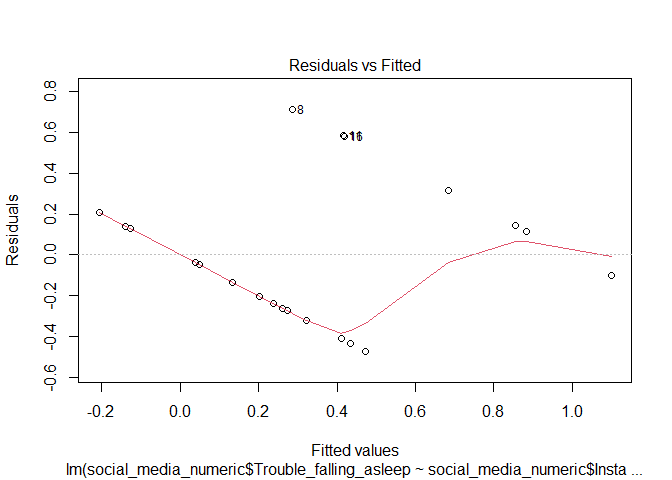

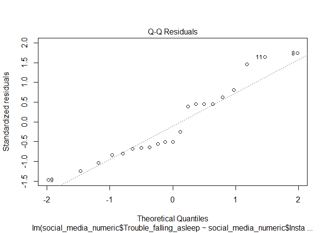

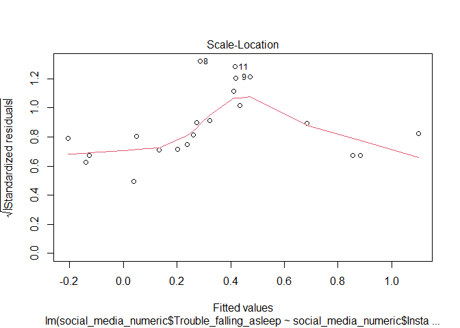

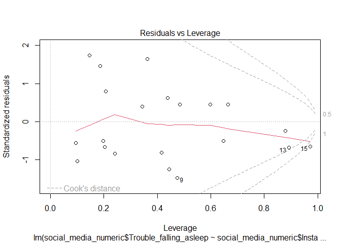

```r
plot(model)
```

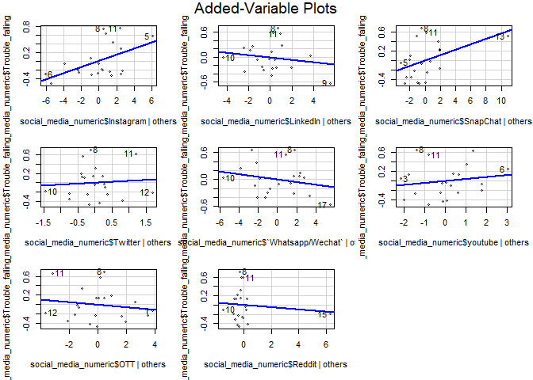

```r
avPlots(model)
```

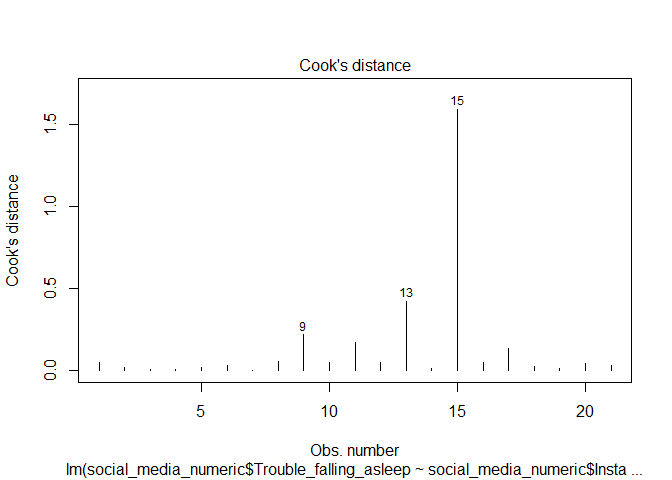

```r
cutoff <- 17/((nrow(social_media)-length(model$coefficients)-2))
plot(model, which=4, cook.levels=cutoff)
```

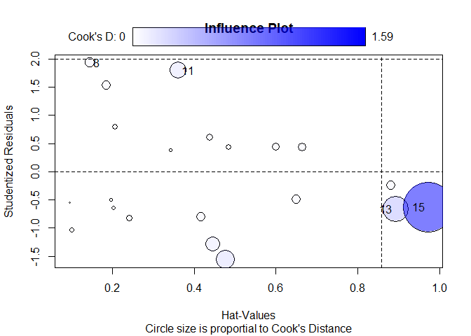

```
##       StudRes       Hat      CookD
## 8   1.9283209 0.1457607 0.05747738
## 11  1.7930758 0.3622253 0.17127619
## 13 -0.6643396 0.8918546 0.42415845
## 15 -0.6322389 0.9714537 1.59103287
```

```r
influencePlot(model, id.method="identify", main="Influence Plot", sub="Circle size is proportial to Cook's Distance" )
```

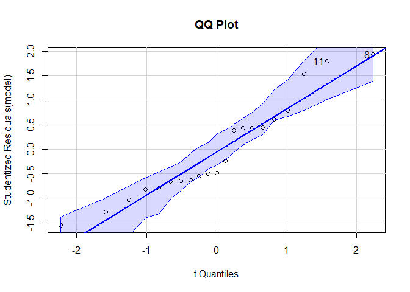

```
## [1]  8 11
```

```r
qqPlot(model, main="QQ Plot")
```

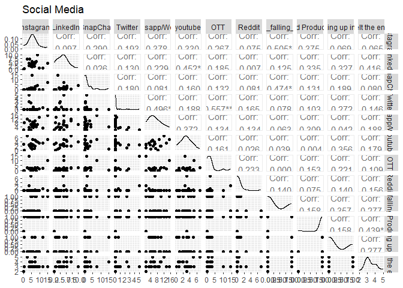

```r
ggpairs(data=social_media_numeric, title="Social Media")
```

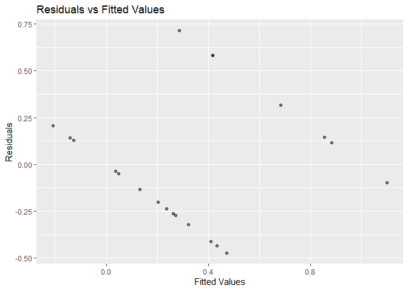

```r
ggplot(social_media_numeric, aes(x = fitted(model), y = residuals(model))) +
  geom_point(alpha = 0.5) +
  labs(title = "Residuals vs Fitted Values", x = "Fitted Values", y = "Residuals")
```

One method for assessing a regression model’s assumptions and suitability is the residual vs. fitted graphic. It is useful in determining whether the model accurately depicts the underlying relationships in the data or whether there are problems that require attention. Plotting a pattern of points around zero indicates that the model is inappropriate.

#### Prediction

```r
new_data_pd <- data.frame(
  character = "masinl",
  Instagram = 3.50,
  LinkedIn = 4.00,
  SnapChat = 1.00,
  Twitter = 5.00,
  `Whatsapp/Wechat` = 1.00,
  youtube = 2.50,
  OTT = 14.50,
  Reddit = 2.50,
  Trouble_falling_asleep = 0,
  Mood = 1,
  Productivity = 0,
  Tired_waking_up_in_morning = 3,
  `How you felt the entire week?` = 3
)

predicted_pd <- predict(model, newdata = new_data_pd)
predicted_pd
```

```
##           1           2           3           4           5           6
##  0.03767577  0.68297470 -0.14111191  0.20249080  0.85568960 -0.12780750
##           7           8           9          10          11          12
##  0.23700749  0.28681294  0.47239558  0.13256374  0.41692826  0.27284963
##          13          14          15          16          17          18
##  1.09915634  0.43420708  0.04857065  0.41826973  0.41113911  0.32212351
##          19          20          21
##  0.26171236  0.88332910 -0.20697699
```

```r
summary(predicted_pd)
```

```
##    Min. 1st Qu.  Median    Mean 3rd Qu.    Max.
## -0.2070  0.1326  0.2868  0.3333  0.4342  1.0992
```

#### Model Accuracy

```r
rsquared <- summary(model)$r.squared
cat("R-squared:", rsquared, "\n")
```

```
## R-squared: 0.494963
```

```r
adjusted_rsquared <- summary(model)$adj.r.squared
cat("Adjusted R-squared:", adjusted_rsquared, "\n")
```

```
## Adjusted R-squared: 0.1582717
```

```r
predictions <- predict(model)
rmse <- sqrt(mean((social_media$Instagram - predictions)^2))
cat("RMSE:", rmse, "\n")
```

```
## RMSE: 6.442152
```